# Generating sets of control and candidate SNPs

Author

Juliette Archambeau

Published

March 23, 2023

```r
# function to make the Venn diagrams
make_venndiagram <- function(list_candidates,
                             caption=""){

list_candidates %>% ggVennDiagram(lty="solid", size=0.2) +
  scale_fill_gradient2(low = "white", high = 'gray40') +
  scale_color_manual(values = rep("gray80",4)) +
  guides(fill = "none") +
  labs(caption=caption) +
  theme(text = element_text(size=16),
        plot.caption = element_text(hjust=0.5, size=rel(1.2))) +
  scale_x_continuous(expand = expansion(mult = .2))
}
```

# GEA methods

Candidate SNPs were identified using different gene-environment association (GEA) methods, which we summarize below.

**Redundancy analysis (RDA)**

Two RDA models were fitted:

- not accounting for population structure, which we will call *RDA-raw*.
- accounting for population structure by incorporating in the RDA model the three first PCs of the PCA performed on the genomic dataset (not filtered for minor allele frequencies), which we will call *RDA-X*.

Candidate SNPs were identified using two different methods:

- based on their *extremeness* along a *distribution of Mahalanobis distances* estimated between each locus and the center of the RDA space using a $K$ number of axes (we used $K=2$). This method was used in Capblancq et al. (2020) (see [code](https://github.com/Capblancq/Local-Adaptation-Fagus-sylvatica)) and Capblancq and Forester (2021) ([code](https://github.com/Capblancq/RDA-landscape-genomics)).
- based on *extreme loadings on each significant axis*. Method used in Forester et al. (2018) (see [code](https://popgen.nescent.org/2018-03-27_RDA_GEA.html)).

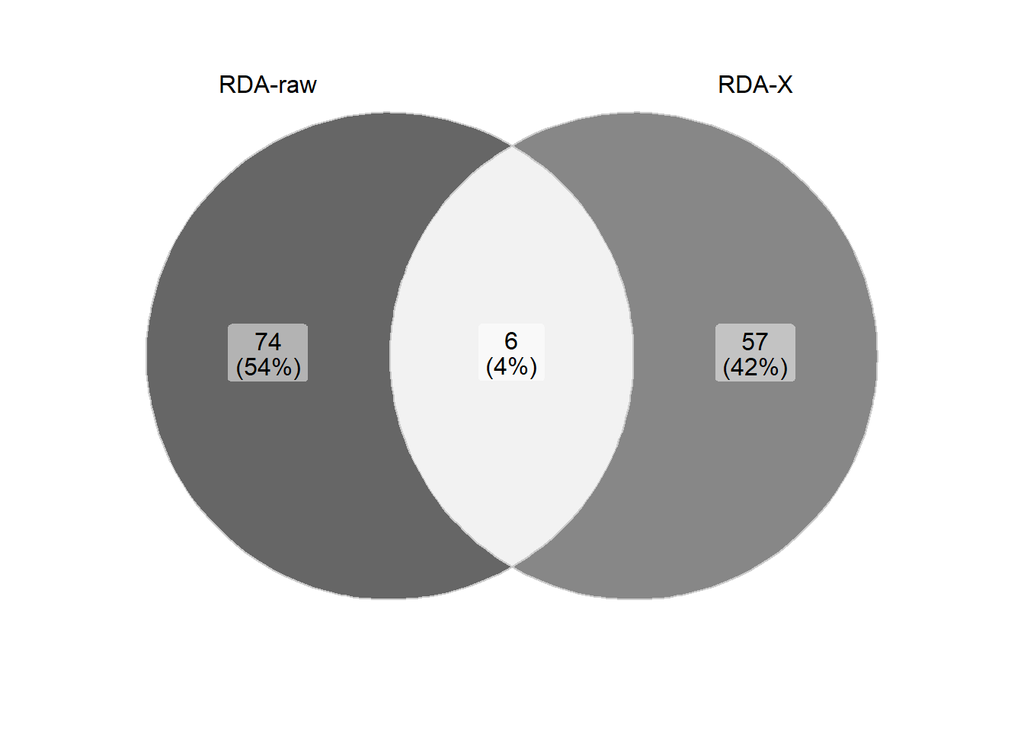

```r
rda_outliers <- readRDS(here::here("outputs/RDA/RDA_outliers.rds"))

list_candidates <- list("RDA-raw"=rda_outliers[[5]]$outliers$snp,
                        "RDA-X"=rda_outliers[[6]]$outliers$snp,
                        "RDA-raw (mahalanobis)"=rda_outliers[[5]]$outliers %>% dplyr::filter(maha_meth==T) %>% pull(snp),
                        "RDA-raw (loadings)"=rda_outliers[[5]]$outliers %>% dplyr::filter(load_meth==T) %>% pull(snp),
                        "RDA-X (mahalanobis)"=rda_outliers[[6]]$outliers %>% dplyr::filter(maha_meth==T) %>% pull(snp),
                        "RDA-X (loadings)"=rda_outliers[[6]]$outliers %>% dplyr::filter(load_meth==T) %>% pull(snp))


make_venndiagram(list_candidates[c("RDA-raw","RDA-X")])
```

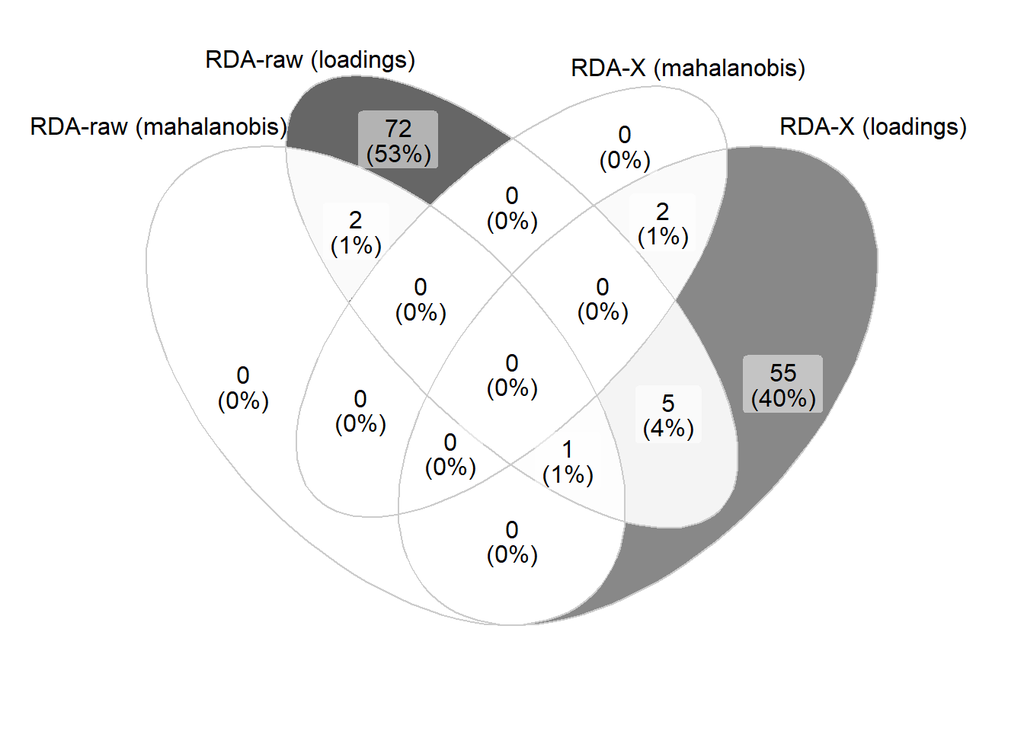

```r
make_venndiagram(list_candidates[c("RDA-raw (mahalanobis)","RDA-raw (loadings)","RDA-X (mahalanobis)","RDA-X (loadings)")])
```

**Gradient forest (GF)**

Following Fitzpatrick et al. (2021) and Capblancq et al. (2023), GF models were fitted using:

- the ‘raw’ or *uncorrected* allele frequencies, which we call *GF-raw*.
- the *corrected* allele frequencies, i.e. the allele frequencies corrected for population structure = corrected for population reladness, which we call *GF-X*

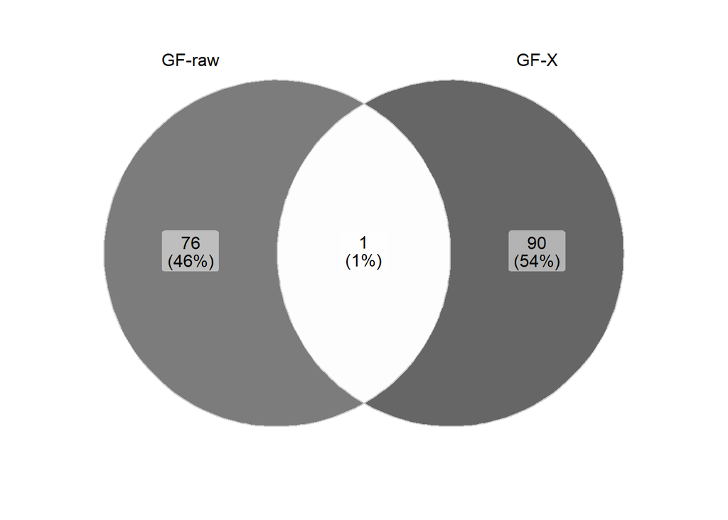

```r
gf_out <- readRDS(here::here("outputs/GF/gf_outliers.rds"))

list_candidates$"GF-raw"=gf_out$gf_raw$set3_var$outliers$outliers001
list_candidates$"GF-X"=gf_out$gf_X$set3_var$outliers$outliers001

make_venndiagram(list_candidates[c("GF-raw","GF-X")])
```

**Latent factor mixed model (LFMM)**

We identified the candidate SNPs by applying a FDR threshold of 10% to the p-values from a LFMM. LFMM was corrected for population structure (ie population relatedness) as the population structure should be captured by the $K$ latent factors ($K = 5$ in our case).

```r
list_candidates$"LFMM" <- readRDS(here::here("outputs/LFMM/candidates.rds"))
```

300 candidate SNPs were identified with the LFMM approach.

# Common candidate SNPs

Let’s look at the common candidates across the different GEA methods.

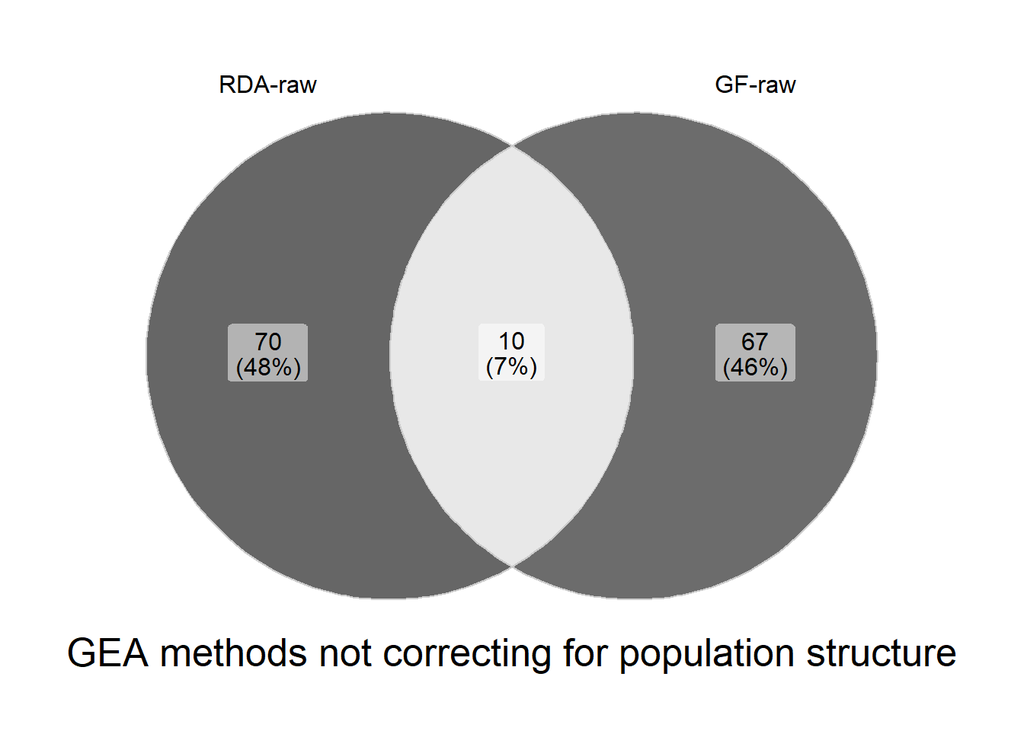

```r
# generating the Venn diagrams showing common candidates across GEA methods
make_venndiagram(list_candidates[c("RDA-raw","GF-raw")],
                 caption = "GEA methods not correcting for population structure")
```

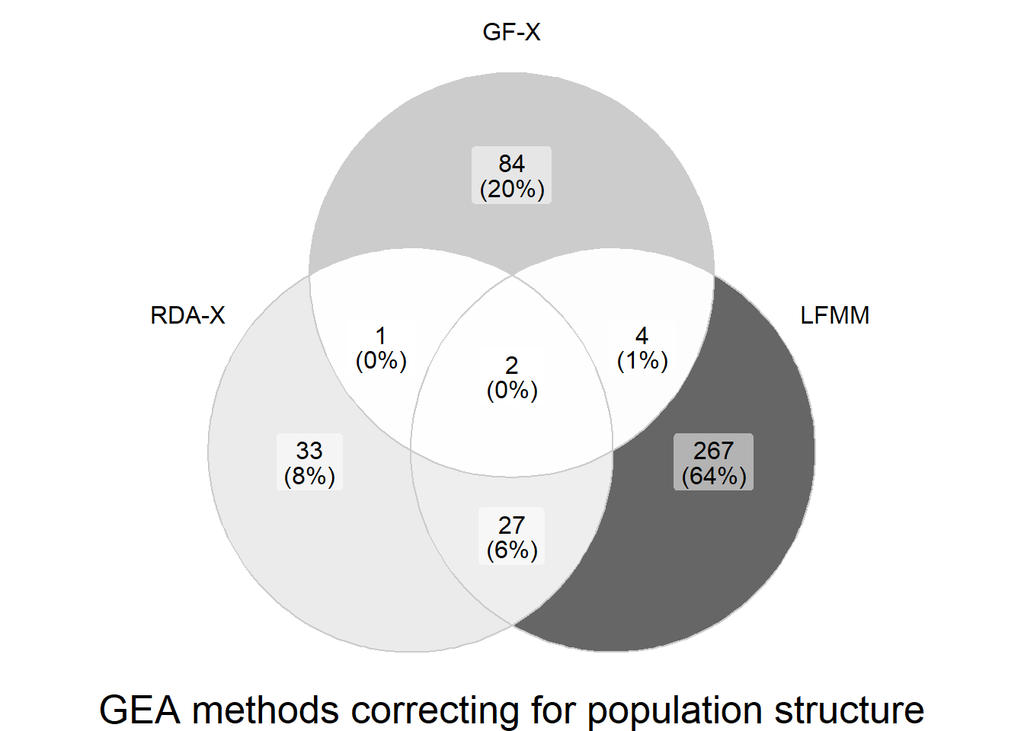

```r
make_venndiagram(list_candidates[c("RDA-X","GF-X","LFMM")],
                 caption = "GEA methods correcting for population structure")
```

```r
# Identifying SNPs identified by at least two GEA methods
common_cand_notcorrected <- list_candidates[c("RDA-raw","GF-raw")] %>% unlist() %>% .[duplicated(.)] %>% unique()
common_cand_corrected <- list_candidates[c("RDA-X","GF-X","LFMM")] %>% unlist() %>% .[duplicated(.)] %>% unique()
```

# Genome position of candidate SNPs

```r
snppos <- read_excel(here("data/GenomicData/genome_position.xlsx"), sheet = "base_table") %>%
  dplyr::rename(snp_ID = Juliette_snp_ID,
                original_ID = Original_ID,
                affx_ID = affy_snp_id,
                infinium_ID = Infinium_ID,
                genome_position =`position (bp)`,
                annotation =`Annotation (including alternative names)`) %>%
  dplyr::select(snp_ID, original_ID, affx_ID, infinium_ID, scaffold, genome_position, annotation)
```

Information on genome position for the set of candidates identified by GEA methods not corrected for population structure:

```r
snppos %>%
  dplyr::filter(snp_ID %in% common_cand_notcorrected) %>%
  kable_mydf(boldfirstcolumn = F, font_size = 11)
```

| snp_ID | original_ID | affx_ID | infinium_ID | scaffold | genome_position | annotation |
| --- | --- | --- | --- | --- | --- | --- |
| snp_54 | 2_3919_01_contig_refait-268 | Affx-979041132 | SNP_0101 | 2_3919_01_contig_refait | 268 | 2_3919_01_contig_refait-268 |
| snp_2276 | F51TW9001ERD0B-1315 | Affx-979045101 | SNP_4991 | F51TW9001ERD0B | 1315 | F51TW9001ERD0B-1315 |
| snp_2278 | F51TW9001ERD0B-942 | Affx-979045103 | SNP_4993 | F51TW9001ERD0B | 942 | F51TW9001ERD0B-942 |
| snp_2811 | sp_v3.0_unigene17903-1441 | Affx-979045944 | SNP_5951 | sp_v3_0_unigene17903 | 1441 | sp_v3_0_unigene17903-1441 |
| snp_2900 | 0_11649_03_contig2-284 | Affx-979228629 | SNP_0007 | 0_11649_03_contig2 | 284 | 0_11649_03_contig2-284 |
| snp_5355 | NA | Affx-979069346 | NA | scaffold_21480 | 1558 | Pinus_pinaster_scaffold_21480_1558 |
| snp_7418 | NA | Affx-979093966 | NA | scaffold_49129 | 524 | Pinus_pinaster_scaffold_49129_524 |
| snp_8187 | NA | Affx-979102908 | NA | scaffold_6545 | 211 | Pinus_pinaster_scaffold_6545_211 |
| snp_9032 | NA | Affx-979112514 | NA | scaffold_87530 | 2484 | Pinus_pinaster_scaffold_87530_2484 |
| snp_9946 | NA | Affx-979146678 | NA | scaffold_24928 | 314 | Pinus_pinaster_scaffold_24928_314 |

Information on genome position for the set of candidates identified by GEA methods corrected for population structure:

```r
snppos %>%
  dplyr::filter(snp_ID %in% common_cand_corrected) %>%
  kable_mydf(boldfirstcolumn = F, font_size = 11)
```

| snp_ID | original_ID | affx_ID | infinium_ID | scaffold | genome_position | annotation |
| --- | --- | --- | --- | --- | --- | --- |
| snp_54 | 2_3919_01_contig_refait-268 | Affx-979041132 | SNP_0101 | 2_3919_01_contig_refait | 268 | 2_3919_01_contig_refait-268 |
| snp_320 | AL750570-930 | Affx-979041645 | SNP_0766 | AL750570 | 930 | AL750570-930 |
| snp_1203 | BX681786-62 | Affx-979043245 | SNP_2744 | BX681786 | 62 | BX681786-62 |
| snp_1241 | BX784086-1351 | Affx-979043326 | SNP_2842 | BX784086 | 1351 | BX784086-1351 |
| snp_1466 | CT574704-1202 | Affx-979043726 | SNP_3367 | CT574704 | 1202 | CT574704-1202 |
| snp_1566 | CT576335-234 | Affx-979043906 | SNP_3563 | CT576335 | 234 | CT576335-234 |
| snp_2206 | F51TW9001CPOV5_349 | Affx-979044993 | SNP_4872 | F51TW9001CPOV5 | 349 | F51TW9001CPOV5-349 |
| snp_2212 | F51TW9001CQUGF-303 | Affx-979045004 | SNP_4883 | F51TW9001CQUGF | 303 | F51TW9001CQUGF-303 |
| snp_2611 | i13311s398pg | Affx-979045645 | SNP_5617 | i13311 | 398 | i13311s398pg |
| snp_2900 | 0_11649_03_contig2-284 | Affx-979228629 | SNP_0007 | 0_11649_03_contig2 | 284 | 0_11649_03_contig2-284 |
| snp_3256 | NA | Affx-979047765 | NA | scaffold_104479 | 638 | Pinus_pinaster_scaffold_104479_638 |
| snp_3257 | NA | Affx-979047767 | NA | scaffold_104479 | 843 | Pinus_pinaster_scaffold_104479_843 |
| snp_3681 | NA | Affx-979052064 | NA | scaffold_12100 | 460 | Pinus_pinaster_scaffold_12100_460 |
| snp_3735 | NA | Affx-979052597 | NA | scaffold_122902 | 364 | Pinus_pinaster_scaffold_122902_364 |
| snp_4182 | NA | Affx-979057653 | NA | scaffold_14467 | 536 | Pinus_pinaster_scaffold_14467_536 |
| snp_4183 | NA | Affx-979057659 | NA | scaffold_14467 | 700 | Pinus_pinaster_scaffold_14467_700 |
| snp_4185 | NA | Affx-979057669 | NA | scaffold_14467 | 964 | Pinus_pinaster_scaffold_14467_964 |
| snp_4380 | NA | Affx-979059736 | NA | scaffold_153990 | 300 | Pinus_pinaster_scaffold_153990_300 |
| snp_5062 | NA | Affx-979066811 | NA | scaffold_195165 | 464 | Pinus_pinaster_scaffold_195165_464 |
| snp_6494 | NA | Affx-979082393 | NA | scaffold_34095 | 1258 | Pinus_pinaster_scaffold_34095_1258 |
| snp_6521 | NA | Affx-979082457 | NA | scaffold_341766 | 632 | Pinus_pinaster_scaffold_341766_632 |
| snp_8187 | NA | Affx-979102908 | NA | scaffold_6545 | 211 | Pinus_pinaster_scaffold_6545_211 |
| snp_8309 | NA | Affx-979104540 | NA | scaffold_68658 | 570 | Pinus_pinaster_scaffold_68658_570 |
| snp_8633 | NA | Affx-979108860 | NA | scaffold_78019 | 548 | Pinus_pinaster_scaffold_78019_548 |
| snp_9344 | NA | Affx-979115701 | NA | scaffold_9766 | 422 | Pinus_pinaster_scaffold_9766_422 |
| snp_9345 | NA | Affx-979115703 | NA | scaffold_9766 | 564 | Pinus_pinaster_scaffold_9766_564 |
| snp_9346 | NA | Affx-979115712 | NA | scaffold_9766 | 1099 | Pinus_pinaster_scaffold_9766_1099 |
| snp_9349 | NA | Affx-979115756 | NA | scaffold_9766 | 2012 | Pinus_pinaster_scaffold_9766_2012 |
| snp_10900 | NA | Affx-979217795 | NA | scaffold_558603 | 76 | Pinus_pinaster_scaffold_558603_76 |
| snp_10982 | 2_1014_01_contig1-48 | NA | SNP_0082 | 2_1014_01_contig1 | 48 | 2_1014_01_contig1-48 |
| snp_12605 | CL3156CT3619CN3872-946 | NA | SNP_3002 | CL3156CT3619CN3872 | 946 | CL3156CT3619CN3872-946 |
| snp_12785 | CT574704-1418 | NA | SNP_3368 | CT574704 | 1418 | CT574704-1418 |
| snp_12868 | CT575893-1455 | NA | SNP_3534 | CT575893 | 1455 | CT575893-1455 |
| snp_13486 | F51TW9001C8ABL-380 | NA | SNP_4805 | F51TW9001C8ABL | 380 | F51TW9001C8ABL-380 |

# Control SNPs

We *randomly* sample a set of SNPs (approximately the same number as the candidate SNPs) among the SNPs that have been identified by none of the GEA methods. This set of SNPs will be used as **control SNPs**.

```r
# names of the SNPs that were identified by at least one GEA method
all_candidates <- list_candidates %>% unlist() %>% unique()

# remove the candidates from the set of SNPs used in the GEA analyses
no_candidates <- read.csv(here("data/DryadRepo/FormattedFilteredGenomicData_AlleleCounts_withoutmaf.csv")) %>%
  pull(snp_ID) %>%
  setdiff(all_candidates)

# sample the set of control SNPs
set.seed(36)
control_snps <- sample(no_candidates,30,replace = F)
```

## References

Capblancq, Thibaut, and Brenna R Forester. 2021. “Redundancy Analysis (RDA): A Swiss Army Knife for Landscape Genomics.” *Methods in Ecology and Evolution*.

Capblancq, Thibaut, Susanne Lachmuth, Matthew C Fitzpatrick, and Stephen R Keller. 2023. “From Common Gardens to Candidate Genes: Exploring Local Adaptation to Climate in Red Spruce.” *New Phytologist* 237 (5): 1590–1605.

Capblancq, Thibaut, Xavier Morin, Maya Gueguen, Julien Renaud, Stéphane Lobreaux, and Eric Bazin. 2020. “Climate-Associated Genetic Variation in Fagus Sylvatica and Potential Responses to Climate Change in the French Alps.” *Journal of Evolutionary Biology* 33 (6): 783–96.

Fitzpatrick, Matthew C, Vikram E Chhatre, Raju Y Soolanayakanahally, and Stephen R Keller. 2021. “Experimental Support for Genomic Prediction of Climate Maladaptation Using the Machine Learning Approach Gradient Forests.” *Molecular Ecology Resources*.

Forester, Brenna R, Jesse R Lasky, Helene H Wagner, and Dean L Urban. 2018. “Comparing Methods for Detecting Multilocus Adaptation with Multivariate Genotype–Environment Associations.” *Molecular Ecology* 27 (9): 2215–33.